# Ejercicio 10+1

2022-11-15

### 1. Definir la semilla a utilizar, que corresponde a los últimos cuatro dígitos del RUN (sin considerar el dígito verificador) del integrante de menor edad del equipo.

```r
# Establece la semilla
set.seed(4566)
#setwd("C:/usach/Semestre 6/Estadística Inferencial/Ejercicio 10+1")

# Lectura de datos
dataset = read.csv2("EP11 Datos.csv")
```

### 2. Seleccionar una muestra de 50 mujeres (si la semilla es un número par) o 50 hombres (si la semilla es impar).

```r
# Filtra las observaciones de las mujeres, dado que la semilla es par
datamujeres = dataset %>% filter(Gender == 0)
# Toma una muestra aleatoria de tamaño 50
samplemujeres = sample_n(datamujeres, 50)
```

### 3. Seleccionar de forma aleatoria ocho posibles variables predictoras.

```r
# Selecciona ocho posibles variables predictoras
# Dado que la columna de peso no salió seleccionada de forma aleatoria, no es necesario excluír la columna "Weight" de la selección
indices_columns <- sample((1:ncol(dataset)),8)
nombres_columnas <- colnames(samplemujeres)
columnas_seleccionadas <- nombres_columnas[indices_columns]
```

### 4. Seleccionar, de las otras variables, una que el equipo considere que podría ser útil para predecir la variable Peso, justificando bien esta selección.

```r
# Se calculan las correlaciones de las variables restantes con "Weight"
correlaciones = cor(samplemujeres$Weight,samplemujeres)
knitr::kable(t(correlaciones),label="Correlaciones con Weight")
```

| Biacromial.diameter | 0.6943960 |
| --- | --- |
| Biiliac.diameter | 0.6128020 |
| Bitrochanteric.diameter | 0.7722407 |
| Chest.depth | 0.6983251 |
| Chest.diameter | 0.6713495 |
| Elbows.diameter | 0.7180278 |
| Wrists.diameter | 0.6940772 |
| Knees.diameter | 0.8026135 |
| Ankles.diameter | 0.6530617 |
| Shoulder.Girth | 0.8168748 |
| Chest.Girth | 0.8645149 |
| Waist.Girth | 0.9030588 |
| Navel.Girth | 0.8569945 |
| Hip.Girth | 0.9277059 |
| Thigh.Girth | 0.8775898 |
| Bicep.Girth | 0.9099195 |
| Forearm.Girth | 0.8641373 |
| Knee.Girth | 0.8339517 |
| Calf.Maximum.Girth | 0.7910981 |
| Ankle.Minimum.Girth | 0.6825741 |
| Wrist.Minimum.Girth | 0.7378480 |
| Age | 0.3071441 |
| Weight | 1.0000000 |
| Height | 0.6375411 |
| Gender | NA |

De la anterior tabla se puede observar para la columna peso (Weight) la variable que mayor correlación tiene es la de ‘Hip.Girth’, por ende, se selecciona tal columna como variable predictora para el peso.

### 5. Usando el entorno R, construir un modelo de regresión lineal simple con el predictor seleccionado en el paso anterior.

```r
col_Hip_Grith <- samplemujeres$Hip.Girth
col_Weight <- samplemujeres$Weight
# Crea un dataframe con la columna "Hip.Girth" que tiene mayor correlación con la columna "Weight"
modelo_lineal <- data.frame(col_Hip_Grith, col_Weight)
# Calcula el modelo de regresión lineal simple
ml = lm(data=samplemujeres, Weight ~ Hip.Girth)
summary(ml)
```

```
##
## Call:
## lm(formula = Weight ~ Hip.Girth, data = samplemujeres)
##
## Residuals:
##     Min      1Q  Median      3Q     Max
## -7.4530 -2.8151 -0.1657  2.1110 10.5805
##
## Coefficients:
##              Estimate Std. Error t value Pr(>|t|)
## (Intercept) -67.09514    7.45673  -8.998 7.14e-12 ***
## Hip.Girth     1.33637    0.07762  17.217  < 2e-16 ***
## ---
## Signif. codes:  0 '***' 0.001 '**' 0.01 '*' 0.05 '.' 0.1 ' ' 1
##
## Residual standard error: 4.137 on 48 degrees of freedom
## Multiple R-squared:  0.8606, Adjusted R-squared:  0.8577
## F-statistic: 296.4 on 1 and 48 DF,  p-value: < 2.2e-16
```

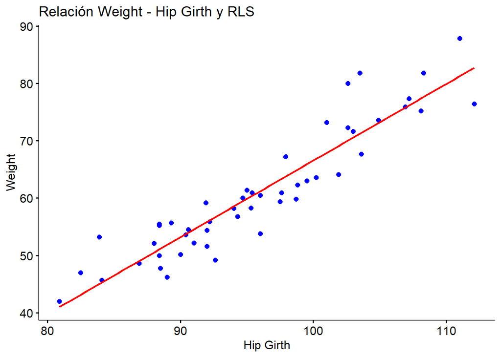

```r
# Grafica el modelo RLS
p <- ggscatter(modelo_lineal, x = "col_Hip_Grith", y ="col_Weight", color="blue", fill="blue", xlab = "Hip Girth", ylab = "Weight",title = "Relación Weight - Hip Girth y RLS",)

p <- p + geom_smooth(method= lm , se = FALSE, color="red")
print(p)
```

### Evaluamos condiciones a fin de que el modelo de regresión lineal sea generalizable En primer lugar, se puede comprobar que las variables predictoras son numéricas y no corresponden a una constante, las observaciones son independientes entre sí y además, la variable de respuesta es numérica a nivel de intervalo sin restricciones.

#### Linealidad

Gracias al gráfico anterior se puede observar una relación lineal, o de crecimiento proporcional, entre Wight y Hip Girht.

```r
cor.test(samplemujeres$Hip.Girth, samplemujeres$Weight)
```

```
##
##  Pearson's product-moment correlation
##
## data:  samplemujeres$Hip.Girth and samplemujeres$Weight
## t = 17.217, df = 48, p-value < 2.2e-16
## alternative hypothesis: true correlation is not equal to 0
## 95 percent confidence interval:
##  0.8754110 0.9585359
## sample estimates:
##       cor
## 0.9277059
```

#### Normalidad de los residuos

```r
shapiro.test(ml$residuals)
```

```
##
##  Shapiro-Wilk normality test
##
## data:  ml$residuals
## W = 0.97298, p-value = 0.3047
```

#### Constancia de los residuos

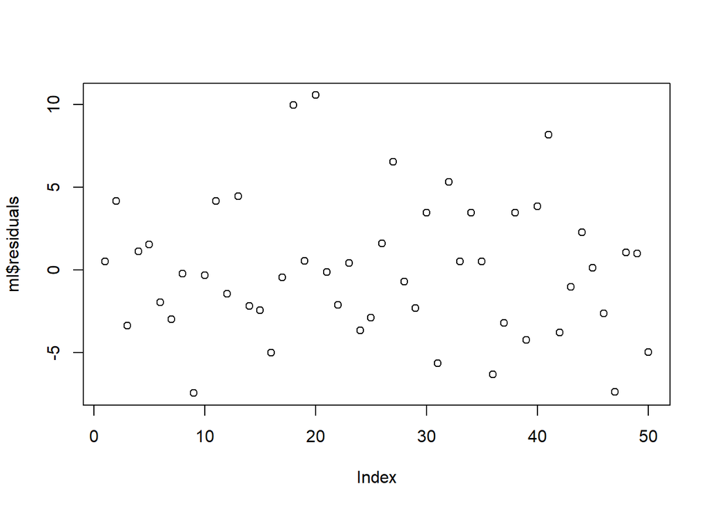

```r
plot(ml$residuals)
```

No se logra observar ninguna clase de seccion cónica y a su vez se percibe una constancia de los residuos.

### 6. Usando herramientas para la exploración de modelos del entorno R, buscar entre dos y cinco predictores de entre las variables seleccionadas al azar en el punto 3, para agregar al modelo de regresión lineal simple obtenido en el paso 5.

#### Recordamos columnas seleccionadas con anterioridad.

```r
# Crea un dataframe con las ocho columnas seleccionadas en la muestra
dataframe_columns_selected <- data.frame(
  Hip.Girth=samplemujeres$Hip.Girth,
  Chest.diameter=samplemujeres$Chest.diameter,
  Biiliac.diameter=samplemujeres$Biiliac.diameter,
  Wrists.diameter=samplemujeres$Wrists.diameter,
  Shoulder.Girth=samplemujeres$Shoulder.Girth,
  Thigh.Girth=samplemujeres$Thigh.Girth,
  Waist.Girth=samplemujeres$Waist.Girth,
  Elbows.diameter=samplemujeres$Elbows.diameter
)
```

```r
# Calcula las correlaciones entre la variable de respuesta "Hip Girth" y las columnas seleccionadas
correlacion4NewModel = cor(samplemujeres$Hip.Girth,dataframe_columns_selected)
knitr::kable(t(correlacion4NewModel))
```

| Hip.Girth | 1.0000000 |
| --- | --- |
| Chest.diameter | 0.5773663 |
| Biiliac.diameter | 0.5745195 |
| Wrists.diameter | 0.6310374 |
| Shoulder.Girth | 0.7375079 |
| Thigh.Girth | 0.9287561 |
| Waist.Girth | 0.8367781 |
| Elbows.diameter | 0.6335686 |

```r
# Agrega las nuevas columnas al modelo de regresión lineal para observar el impacto que tienen sobre este
columnas_string = c(paste("samplemujeres",columnas_seleccionadas,sep="$"))
mlm_2_table = add1(ml, scope =columnas_string ,scale = 0, test = c("none", "Chisq", "F"),x = NULL, k = 2)
mlm_2_dtf = data.frame(variables=c("sin cambios",columnas_string),AIC=mlm_2_table$AIC)
mlm_2_dtf
```

| variables | AIC |
| --- | --- |
| sin cambios | 143.9677 |
| samplemujeres$Chest.diameter | 134.9182 |
| samplemujeres$Biiliac.diameter | 142.4339 |
| samplemujeres$Wrists.diameter | 138.3810 |
| samplemujeres$Shoulder.Girth | 129.7516 |
| samplemujeres$Thigh.Girth | 145.2967 |
| samplemujeres$Knee.Girth | 130.4179 |
| samplemujeres$Waist.Girth | 121.6880 |
| samplemujeres$Elbows.diameter | 134.5972 |

```r
mlm_2 = update(ml, . ~ . + samplemujeres$Shoulder.Girth)
anova(ml,mlm_2)
```

|  | Res.Df | RSS | Df | Sum of Sq | F | Pr(>F) |
| --- | --- | --- | --- | --- | --- | --- |
| 1 | 48 | 821.7018 | NA | NA | NA | NA |
| 2 | 47 | 594.1046 | 1 | 227.5972 | 18.00537 | 0.0001027097 |

De esta prueba anova sobre ambos modelos se obtiene un valor p inferior a 0.05, en consecuencia el modelo con más complejidad, es decir el que tiene más variables predictoras, es mejor.

#### Correlaciones entre Hip Girth y Shoulder Girth con las columnas seleccionadas.

```r
correlacion4NewModel = cor(data.frame(Hip.Girth=samplemujeres$Hip.Girth,Shoulder.Girth=samplemujeres$Shoulder.Girth),dataframe_columns_selected)
knitr::kable(t(correlacion4NewModel))
```

|  | Hip.Girth | Shoulder.Girth |
| --- | --- | --- |
| Hip.Girth | 1.0000000 | 0.7375079 |
| Chest.diameter | 0.5773663 | 0.8326769 |
| Biiliac.diameter | 0.5745195 | 0.3047370 |
| Wrists.diameter | 0.6310374 | 0.6400055 |
| Shoulder.Girth | 0.7375079 | 1.0000000 |
| Thigh.Girth | 0.9287561 | 0.7146450 |
| Waist.Girth | 0.8367781 | 0.7691892 |
| Elbows.diameter | 0.6335686 | 0.6918930 |

```r
columnas_string = c(paste("samplemujeres",columnas_seleccionadas,sep="$"))
mlm_3_table = add1(mlm_2, scope =columnas_string ,scale = 0, test = c("none", "Chisq", "F"),x = NULL, k = 3)
mlm_3_dtf = data.frame(variables=c("sin cambios",columnas_string),AIC=mlm_3_table$AIC)
mlm_3_dtf
```

| variables | AIC |
| --- | --- |
| sin cambios | 132.7516 |
| samplemujeres$Chest.diameter | 135.2569 |
| samplemujeres$Biiliac.diameter | 124.3813 |
| samplemujeres$Wrists.diameter | 132.5453 |
| samplemujeres$Shoulder.Girth | 132.7516 |
| samplemujeres$Thigh.Girth | 135.5538 |
| samplemujeres$Knee.Girth | 125.5057 |
| samplemujeres$Waist.Girth | 119.9193 |
| samplemujeres$Elbows.diameter | 131.2718 |

```r
mlm_3 = update(mlm_2, . ~ . + samplemujeres$Biiliac.diameter)
anova(mlm_2,mlm_3)
```

|  | Res.Df | RSS | Df | Sum of Sq | F | Pr(>F) |
| --- | --- | --- | --- | --- | --- | --- |
| 1 | 47 | 594.1046 | NA | NA | NA | NA |
| 2 | 46 | 473.2620 | 1 | 120.8425 | 11.74562 | 0.001294918 |

Gracias al valor p que se obtiene de la prueba anova que se aplica a los modelos de 2 y 3 predictores, se puede mencionar que el modelo más complejo es mejor.

### 7. Evaluar los modelos y “arreglarlos” en caso de que tengan algún problema con las condiciones que deben cumplir.

```r
columnas_por_eliminar = c("samplemujeres$Shoulder.Girth","Hip.Girth")
better_mlm_2_table = drop1(mlm_3, scope=columnas_por_eliminar, k=2, test = c("none", "Chisq", "F"),x = NULL)
better_mlm_2_dtf = data.frame(variables=c("sin cambios",columnas_por_eliminar),AIC=better_mlm_2_table$AIC)
better_mlm_2_dtf
```

| variables | AIC |
| --- | --- |
| sin cambios | 120.3813 |
| samplemujeres$Shoulder.Girth | 142.4339 |
| Hip.Girth | 160.6053 |

Si bien es cierto, que eliminar cualquiera de los dos empeora nuestro modelo, dejaría de existir colinealidad. En consecuencia, se decide eliminar Shoulder Girth.

```r
better_mlm_2 = mlm_3 = update(mlm_2, . ~ . - samplemujeres$Shoulder.Girth)
```

## 8. Evaluar el poder predictivo del modelo en datos no utilizados para construirlo (o utilizando validación cruzada).

```r
rlm <- train (Hip.Girth ~ Biiliac.diameter, data = dataframe_columns_selected,
              method = "lm",
              trControl = trainControl(method = "cv", number = 10))
summary(rlm)
```

```
##
## Call:
## lm(formula = .outcome ~ ., data = dat)
##
## Residuals:
##     Min      1Q  Median      3Q     Max
## -11.039  -4.638  -0.094   3.817  20.010
##
## Coefficients:
##                  Estimate Std. Error t value Pr(>|t|)
## (Intercept)       47.8267     9.8992   4.831 1.43e-05 ***
## Biiliac.diameter   1.7582     0.3615   4.863 1.28e-05 ***
## ---
## Signif. codes:  0 '***' 0.001 '**' 0.01 '*' 0.05 '.' 0.1 ' ' 1
##
## Residual standard error: 6.297 on 48 degrees of freedom
## Multiple R-squared:  0.3301, Adjusted R-squared:  0.3161
## F-statistic: 23.65 on 1 and 48 DF,  p-value: 1.283e-05
```

```r
predicciones <- predict(rlm, dataframe_columns_selected)
predicciones
```

```
##         1         2         3         4         5         6         7         8
##  96.70383  89.14369  92.83585 100.39599 101.27508  99.16527  95.82475  95.82475
##         9        10        11        12        13        14        15        16
##  96.70383  97.05547 106.37377  97.40710  95.82475  98.46200  99.51691  94.06657
##        17        18        19        20        21        22        23        24
##  91.60513 101.27508  94.59403 102.85743  97.93455  94.59403  90.55023 100.39599
##        25        26        27        28        29        30        31        32
##  96.87965  90.55023 103.73652  97.23128  90.19860  93.89076  94.24239  97.75873
##        33        34        35        36        37        38        39        40
##  94.59403  95.12148  97.93455 103.56070  94.94566  93.53912  91.78095  93.53912
##        41        42        43        44        45        46        47        48
##  93.01167  90.72605  92.83585 100.92344  94.59403  95.82475  88.96788  82.99009
##        49        50
##  91.78095  97.05547
```